# tutorial_1

Lir Hoxhaj

2025-01-09

# Background

**GOALS OF TUTORIAL**: 1. Understand RCT and how we can analyse the impact of an experiment by analysing random groups using statistical methods 2. Run a single and a multiple variable regression using OLS method 3. Be able to interpret results and understand key indicators in regression table

**Sources**: - Spotify data: https://www.kaggle.com/datasets/maharshipandya/-spotify-tracks-dataset?select=dataset.csv - Climate data: https://www.kaggle.com/datasets/tarunrm09/climate-change-indicators - Cognitive data: https://github.com/ryanfalck/R_Help - Smoker data: https://www.kaggle.com/datasets/harrywang/propensity-score-matching?resource=download&select=smoker.csv

# Setup

Let’s set up a new environment and load our libraries in one place.

```r
rm( list = ls(all.names = TRUE) )

## Installing libraries

#install.packages("readxl")
#install.packages("rdrobust")
if(!require(readxl)) install.packages("readxl")
if(!require(rdrobust)) install.packages("rdrobust")
if(!require(AER)) install.packages("AER",repos = "http://cran.us.r-project.org")
if(!require(tidyr)) install.packages("tidyr")
```

```r
if(!require(scatterplot3d)) install.packages("scatterplot3d")
## Loading libraries
library(rstudioapi)
library(readxl)
library(dplyr)
library(ggplot2)
library(rdrobust)
library(AER)
library(corrplot)
```

Setting up our working directory

```r
# Automatically (based on location of this script)
working_directory <- dirname(rstudioapi::getActiveDocumentContext()$path)

# , or manually...
# setwd("C:\\Users\\lhoxhaj\\OneDrive - Imperial College London\\Desktop\\TA\\Shuang\\Tutorials\\Lir\\tutorial_1") # set wd
# rct_data <- read_excel("rct_data.xlsx") # read data
```

# 1. RCT

## Motivation

A randomised-controlled trial is characterised by random assignment of units (individuals, firms, etc.) to treatment and control groups (sometimes, even more).

Idea: assigning subjects randomly to treatment and control groups, they will be comparable on average. In other words, same characteristics on both sides (e.g., proportion of males to females, age distribution, etc.), so that any other factors that may influence X and y is roughly the same on both sides.

$$\Large \text{Sample size} \uparrow
\longrightarrow \text{robustness} \uparrow$$

RCTs, in terms of statistical methods and interpretation of results, are simpler to understand than a simple linear regression (which is the bread and butter of any econometrician). The main focus is data and experiment!

For a treatment $D_i$ (1 = received treatment / 0 = not received treatment), we study outcome $Y_i$ of subject, namely $Y_{0i}$ if not received treatment and $Y_{1i}$ if received treatment. To know if the experiment (treatment) had an impact on the subjects, we want to know the **average treatment effect (ATE)**:

$$\Large E[Y_{1i} - Y_{0i}]$$
, or **average effect of treatment on the treated (ATT)**:

$$\Large E[Y_{1i} - Y_{0i} | D_i =
1]$$

In reality, when we compare the outcome across treatment and control, we have:

$$\Large E[Y_{1i} | D_i = 1] - E[Y_{0i} |
D_i = 0] = E[Y_{1i} | D_i = 1] - E[Y_{0i} | D_i = 1] + E[Y_{0i} | D_i =
1] - E[Y_{0i} | D_i = 0]$$

The first two terms ATT, basically capturing the impact of treatment on the treated and not treated - this is what we want to estimate. Third and fourth terms capture the difference in outcome across the two groups in the hypothetical situation that nobody receives treatment. This is a *selection bias* (e.g., people that were already sick were going to the hospital).

By randomisation, if sample size is large, groups will be comparable before treatment, so that their expected outcome before treatment is the same,

$$\Large E[Y_{0i} | D_i = 1] = E[Y_{0i} |
D_i = 0]$$

and will only change when one gets treated and one does not get treated. This removes selection bias (groups will be comparable). The difference in outcomes after treatment will then be the impact of the treatment.

What about the cons of RCTs? - If not balanced, biased results! - contamination and changed behaviour (*Hawthorne* and *John Henry* effects, for treatment and control groups, respectively) - Attrition (discontinuity of data)

## Cognitive ability data

### Data processing

```r
# Loading dataset
cog_data <- read_excel( paste0( working_directory, "/rct_data.xlsx"))
```

```r
cat("Summary of variables:\n")
```

```
## Summary of variables:
```

```r
summary(cog_data)
```

```
##       ID                 Time      Group                Age
##  Length:120         Min.   :1   Length:120         Min.   :56.00
##  Class :character   1st Qu.:1   Class :character   1st Qu.:68.50
##  Mode  :character   Median :2   Mode  :character   Median :73.00
##                     Mean   :2                      Mean   :71.72
##                     3rd Qu.:3                      3rd Qu.:75.25
##                     Max.   :3                      Max.   :83.00
##
##       Sex         Education    Height (cm)      Weight (kg)     BMI (kg/m2)
##  Min.   :0.00   Min.   :1.0   Min.   : 40.47   Min.   :148.2   Min.   :17.83
##  1st Qu.:0.00   1st Qu.:1.0   1st Qu.: 71.50   1st Qu.:161.2   1st Qu.:25.58
##  Median :0.00   Median :2.0   Median : 82.35   Median :172.4   Median :28.65
##  Mean   :0.35   Mean   :1.9   Mean   : 81.01   Mean   :168.9   Mean   :28.18
##  3rd Qu.:1.00   3rd Qu.:3.0   3rd Qu.: 91.00   3rd Qu.:176.0   3rd Qu.:29.78
##  Max.   :1.00   Max.   :3.0   Max.   :115.70   Max.   :186.4   Max.   :37.42
##
##  ADAS-Cog Total        6MWT
##  Min.   : 1.667   Min.   : 17.0
##  1st Qu.: 6.667   1st Qu.:241.0
##  Median :10.167   Median :353.0
##  Mean   :10.648   Mean   :331.2
##  3rd Qu.:14.000   3rd Qu.:434.0
##  Max.   :27.000   Max.   :600.0
##  NA's   :4        NA's   :6
```

```r
cat("\nColumn names:")
```

```
##
## Column names:
```

```r
colnames(cog_data)
```

```
##  [1] "ID"             "Time"           "Group"          "Age"
##  [5] "Sex"            "Education"      "Height (cm)"    "Weight (kg)"
##  [9] "BMI (kg/m2)"    "ADAS-Cog Total" "6MWT"
```

Renaming vars

```r
cog_data <- cog_data %>%
  rename("Height" = "Height (cm)",
         "Weight" = "Weight (kg)",
         "BMI" = "BMI (kg/m2)",
         "Meters_Walked" = "6MWT",
         "ADAS_COG" = "ADAS-Cog Total")
```

Changing values

```r
cog_data$Education[cog_data$Education==3]<- "High School or Less"
cog_data$Education[cog_data$Education==2]<- "Trade School"
cog_data$Education[cog_data$Education==1]<- "University"

cog_data$Sex[cog_data$Sex==1]<-"Male"
cog_data$Sex[cog_data$Sex==0]<-"Female"

cog_data <- na.omit(cog_data)
```

Let’s assume that we ran an intervention to improve walking fitness (i.e., 6MWT or “Meters Walked”). A secondary outcome would be cognitive performance measured using the ADAS-Cog. There were three time points: Baseline (Time=1), Midpoint (Time=2; 3 months), and Final (Time=3; 6 months). The primary endpoint of the intervention is 6 months.INT= experimental group; CON= control group.

### Results

```r
cog_data_t1 <- cog_data %>%
  filter(Time == 1)
cog_data_t2 <- cog_data %>%
  filter(Time == 2)
cog_data_t3 <- cog_data %>%
  filter(Time == 3)

# Print overall data statistics
cat("All data:\n")
```

```
## All data:
```

```r
cat("- Mean of distance walked:", mean(cog_data$Meters_Walked), "\n")
```

```
## - Mean of distance walked: 331.1842
```

```r
cat("- Mean of distance walked if treatment == 0:", mean(cog_data$Meters_Walked[cog_data$Group == "CON"]), "\n")
```

```
## - Mean of distance walked if treatment == 0: 308.6842
```

```r
cat("- Mean of distance walked if treatment == 1:", mean(cog_data$Meters_Walked[cog_data$Group == "INT"]), "\n")
```

```
## - Mean of distance walked if treatment == 1: 353.6842
```

```r
cat("- Mean of cognitive ability:", mean(cog_data$ADAS_COG), "\n")
```

```
## - Mean of cognitive ability: 10.72041
```

```r
cat("- Mean of distance walked if treatment == 0:", mean(cog_data$ADAS_COG[cog_data$Group == "CON"]), "\n")
```

```
## - Mean of distance walked if treatment == 0: 10.63965
```

```r
cat("- Mean of distance walked if treatment == 1:", mean(cog_data$ADAS_COG[cog_data$Group == "INT"]), "\n")
```

```
## - Mean of distance walked if treatment == 1: 10.80117
```

```r
cat("Baseline (Time=1)\n")
```

```
## Baseline (Time=1)
```

```r
cat("- Mean of distance walked:", mean(cog_data_t1$Meters_Walked), "\n")
```

```
## - Mean of distance walked: 323.45
```

```r
cat("- Mean of distance walked if treatment == 0:", mean(cog_data_t1$Meters_Walked[cog_data_t1$Group == "CON"]), "\n")
```

```
## - Mean of distance walked if treatment == 0: 279.5
```

```r
cat("- Mean of distance walked if treatment == 1:", mean(cog_data_t1$Meters_Walked[cog_data_t1$Group == "INT"]), "\n")
```

```
## - Mean of distance walked if treatment == 1: 367.4
```

```r
cat("- Mean of cognitive ability:", mean(cog_data_t1$ADAS_COG), "\n")
```

```
## - Mean of cognitive ability: 10.74442
```

```r
cat("- Mean of distance walked if treatment == 0:", mean(cog_data_t1$ADAS_COG[cog_data_t1$Group == "CON"]), "\n")
```

```
## - Mean of distance walked if treatment == 0: 10.6555
```

```r
cat("- Mean of distance walked if treatment == 1:", mean(cog_data_t1$ADAS_COG[cog_data_t1$Group == "INT"]), "\n")
```

```
## - Mean of distance walked if treatment == 1: 10.83333
```

```r
cat("Midpoint (Time=2; 3 months)\n")
```

```
## Midpoint (Time=2; 3 months)
```

```r
cat("- Mean of distance walked:", mean(cog_data_t2$Meters_Walked), "\n")
```

```
## - Mean of distance walked: 328.7375
```

```r
cat("- Mean of distance walked if treatment == 0:", mean(cog_data_t2$Meters_Walked[cog_data_t2$Group == "CON"]), "\n")
```

```
## - Mean of distance walked if treatment == 0: 317.3
```

```r
cat("- Mean of distance walked if treatment == 1:", mean(cog_data_t2$Meters_Walked[cog_data_t2$Group == "INT"]), "\n")
```

```
## - Mean of distance walked if treatment == 1: 340.175
```

```r
cat("- Mean of cognitive ability:", mean(cog_data_t2$ADAS_COG), "\n")
```

```
## - Mean of cognitive ability: 10.19208
```

```r
cat("- Mean of distance walked if treatment == 0:", mean(cog_data_t2$ADAS_COG[cog_data_t2$Group == "CON"]), "\n")
```

```
## - Mean of distance walked if treatment == 0: 10.23417
```

```r
cat("- Mean of distance walked if treatment == 1:", mean(cog_data_t2$ADAS_COG[cog_data_t2$Group == "INT"]), "\n")
```

```
## - Mean of distance walked if treatment == 1: 10.15
```

```r
cat("Final (Time=3; 6 months)\n")
```

```
## Final (Time=3; 6 months)
```

```r
cat("- Mean of distance walked:", mean(cog_data_t3$Meters_Walked), "\n")
```

```
## - Mean of distance walked: 343.1618
```

```r
cat("- Mean of distance walked if treatment == 0:", mean(cog_data_t3$Meters_Walked[cog_data_t3$Group == "CON"]), "\n")
```

```
## - Mean of distance walked if treatment == 0: 332.8824
```

```r
cat("- Mean of distance walked if treatment == 1:", mean(cog_data_t3$Meters_Walked[cog_data_t3$Group == "INT"]), "\n")
```

```
## - Mean of distance walked if treatment == 1: 353.4412
```

```r
cat("- Mean of cognitive ability:", mean(cog_data_t3$ADAS_COG), "\n")
```

```
## - Mean of cognitive ability: 11.31373
```

```r
cat("- Mean of distance walked if treatment == 0:", mean(cog_data_t3$ADAS_COG[cog_data_t3$Group == "CON"]), "\n")
```

```
## - Mean of distance walked if treatment == 0: 11.09804
```

```r
cat("- Mean of distance walked if treatment == 1:", mean(cog_data_t3$ADAS_COG[cog_data_t3$Group == "INT"]), "\n")
```

```
## - Mean of distance walked if treatment == 1: 11.52941
```

```r
mean_data_meters <- cog_data %>%
  group_by(Time, Group) %>%
  summarise(
    Mean_Meters_Walked = mean(Meters_Walked, na.rm = TRUE)
  ) %>%
  pivot_longer(cols = c(Mean_Meters_Walked),
               names_to = "Variable",
               values_to = "Mean_Value")
mean_data_cog <- cog_data %>%
  group_by(Time, Group) %>%
  summarise(
    Mean_Cog = mean(ADAS_COG, na.rm = TRUE)
  ) %>%
  pivot_longer(cols = c(Mean_Cog),
               names_to = "Variable",
               values_to = "Mean_Value")
```

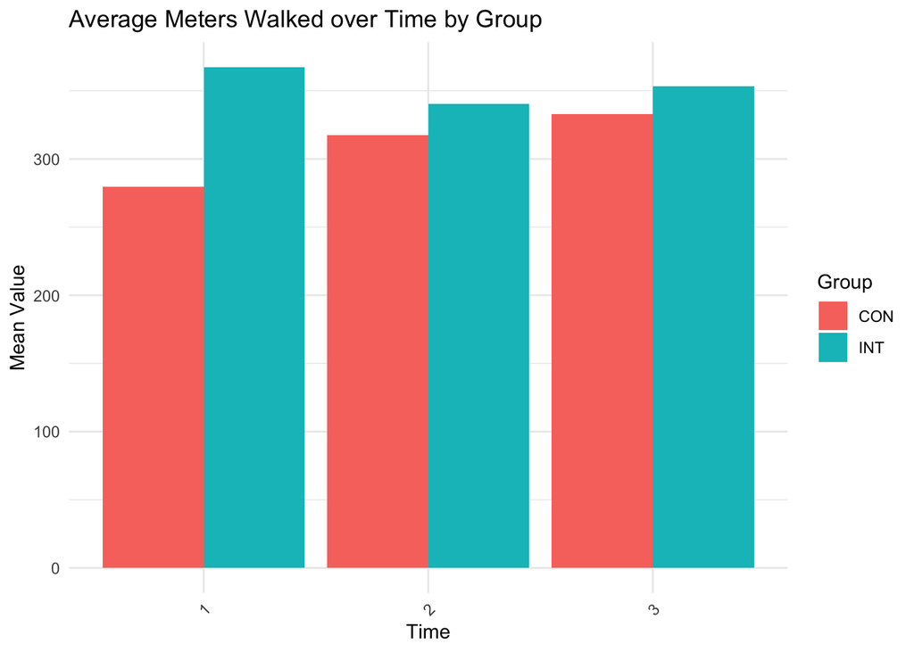

```r
ggplot(mean_data_meters, aes(x = factor(Time), y = Mean_Value, fill = Group)) +
  geom_bar(stat = "identity", position = "dodge") +  # Grouped bars for each Group
  labs(
    title = "Average Meters Walked over Time by Group",
    x = "Time",
    y = "Mean Value",
    fill = "Group"
  ) +
  theme_minimal() +
  theme(axis.text.x = element_text(angle = 45, hjust = 1))
```

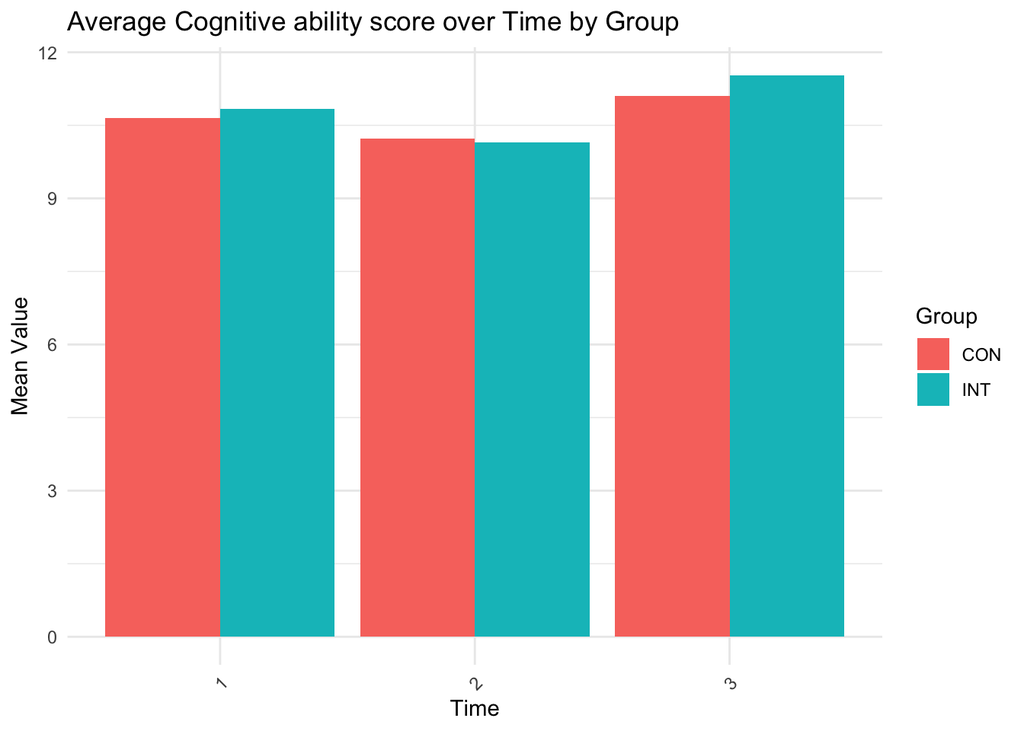

```r
ggplot(mean_data_cog, aes(x = factor(Time), y = Mean_Value, fill = Group)) +
  geom_bar(stat = "identity", position = "dodge") +  # Grouped bars for each Group
  labs(
    title = "Average Cognitive ability score over Time by Group",
    x = "Time",
    y = "Mean Value",
    fill = "Group"
  ) +
  theme_minimal() +
  theme(axis.text.x = element_text(angle = 45, hjust = 1))
```

```r
# Compare meters walked between groups in different periods
t_test_t1 <- t.test(Meters_Walked ~ Group, data = cog_data_t1)
t_test_t2 <- t.test(Meters_Walked ~ Group, data = cog_data_t2)
t_test_t3 <- t.test(Meters_Walked ~ Group, data = cog_data_t3)
print(t_test_t1)
```

```
##
##  Welch Two Sample t-test
##
## data:  Meters_Walked by Group
## t = -2.2422, df = 37.175, p-value = 0.031
## alternative hypothesis: true difference in means between group CON and group INT is not equal to 0
## 95 percent confidence interval:
##  -167.320806   -8.479194
## sample estimates:
## mean in group CON mean in group INT
##             279.5             367.4
```

```r
print(t_test_t2)
```

```
##
##  Welch Two Sample t-test
##
## data:  Meters_Walked by Group
## t = -0.47481, df = 37.804, p-value = 0.6377
## alternative hypothesis: true difference in means between group CON and group INT is not equal to 0
## 95 percent confidence interval:
##  -120.42049   74.67049
## sample estimates:
## mean in group CON mean in group INT
##           317.300           340.175
```

```r
print(t_test_t3)
```

```
##
##  Welch Two Sample t-test
##
## data:  Meters_Walked by Group
## t = -0.43533, df = 31.835, p-value = 0.6663
## alternative hypothesis: true difference in means between group CON and group INT is not equal to 0
## 95 percent confidence interval:
##  -116.77403   75.65639
## sample estimates:
## mean in group CON mean in group INT
##          332.8824          353.4412
```

```r
# Compare cog ability between groups in different periods
t_test_t1 <- t.test(ADAS_COG ~ Group, data = cog_data_t1)
t_test_t2 <- t.test(ADAS_COG ~ Group, data = cog_data_t2)
t_test_t3 <- t.test(ADAS_COG ~ Group, data = cog_data_t3)
print(t_test_t1)
```

```
##
##  Welch Two Sample t-test
##
## data:  ADAS_COG by Group
## t = -0.099746, df = 32.151, p-value = 0.9212
## alternative hypothesis: true difference in means between group CON and group INT is not equal to 0
## 95 percent confidence interval:
##  -3.808721  3.453054
## sample estimates:
## mean in group CON mean in group INT
##          10.65550          10.83333
```

```r
print(t_test_t2)
```

```
##
##  Welch Two Sample t-test
##
## data:  ADAS_COG by Group
## t = 0.056907, df = 37.776, p-value = 0.9549
## alternative hypothesis: true difference in means between group CON and group INT is not equal to 0
## 95 percent confidence interval:
##  -2.910563  3.078897
## sample estimates:
## mean in group CON mean in group INT
##          10.23417          10.15000
```

```r
print(t_test_t3)
```

```
##
##  Welch Two Sample t-test
##
## data:  ADAS_COG by Group
## t = -0.27221, df = 25.621, p-value = 0.7876
## alternative hypothesis: true difference in means between group CON and group INT is not equal to 0
## 95 percent confidence interval:
##  -3.691127  2.828382
## sample estimates:
## mean in group CON mean in group INT
##          11.09804          11.52941
```

You may also use ANOVA if there are more than two groups…

## Smoker data

```r
smoker_data <- read.csv( paste0( working_directory, "/smoker.csv"))
cat("Summary of variables:\n")
```

```
## Summary of variables:
```

```r
summary(smoker_data)
```

```
##      smoker         treatment         outcome
##  Min.   :0.0000   Min.   :0.0000   Min.   :0.0000
##  1st Qu.:0.0000   1st Qu.:0.0000   1st Qu.:0.0000
##  Median :0.0000   Median :0.0000   Median :0.0000
##  Mean   :0.3025   Mean   :0.3004   Mean   :0.2667
##  3rd Qu.:1.0000   3rd Qu.:1.0000   3rd Qu.:1.0000
##  Max.   :1.0000   Max.   :1.0000   Max.   :1.0000
```

```r
cat("\nColumn names:")
```

```
##
## Column names:
```

```r
colnames(smoker_data)
```

```
## [1] "smoker"    "treatment" "outcome"
```

```r
smoker_data_smoker <- smoker_data %>%
  filter(smoker == 1)
smoker_data_nosmoker <- smoker_data %>%
  filter(smoker == 0)

# Print overall data statistics
cat("All data:\n")
```

```
## All data:
```

```r
cat("- Mean of treatment:", mean(smoker_data$treatment), "\n")
```

```
## - Mean of treatment: 0.3004
```

```r
cat("- Mean of outcome:", mean(smoker_data$outcome), "\n\n")
```

```
## - Mean of outcome: 0.2667
```

```r
# Print smoker statistics
cat("Smoker:\n")
```

```
## Smoker:
```

```r
cat("- Mean of treatment:", mean(smoker_data_smoker$treatment), "\n")
```

```
## - Mean of treatment: 0.553719
```

```r
cat("- Mean of outcome:", mean(smoker_data_smoker$outcome), "\n")
```

```
## - Mean of outcome: 0.6357025
```

```r
cat("- Mean of outcome if treatment == 0:", mean(smoker_data_smoker$outcome[smoker_data_smoker$treatment == 0]), "\n")
```

```
## - Mean of outcome if treatment == 0: 0.7948148
```

```r
cat("- Mean of outcome if treatment == 1:", mean(smoker_data_smoker$outcome[smoker_data_smoker$treatment == 1]), "\n\n")
```

```
## - Mean of outcome if treatment == 1: 0.5074627
```

```r
# Print non-smoker statistics
cat("Non-smoker:\n")
```

```
## Non-smoker:
```

```r
cat("- Mean of treatment:", mean(smoker_data_nosmoker$treatment), "\n")
```

```
## - Mean of treatment: 0.1905376
```

```r
cat("- Mean of outcome:", mean(smoker_data_nosmoker$outcome), "\n")
```

```
## - Mean of outcome: 0.1066667
```

```r
cat("- Mean of outcome if treatment == 0:", mean(smoker_data_nosmoker$outcome[smoker_data_nosmoker$treatment == 0]), "\n")
```

```
## - Mean of outcome if treatment == 0: 0.1013107
```

```r
cat("- Mean of outcome if treatment == 1:", mean(smoker_data_nosmoker$outcome[smoker_data_nosmoker$treatment == 1]), "\n")
```

```
## - Mean of outcome if treatment == 1: 0.1294206
```

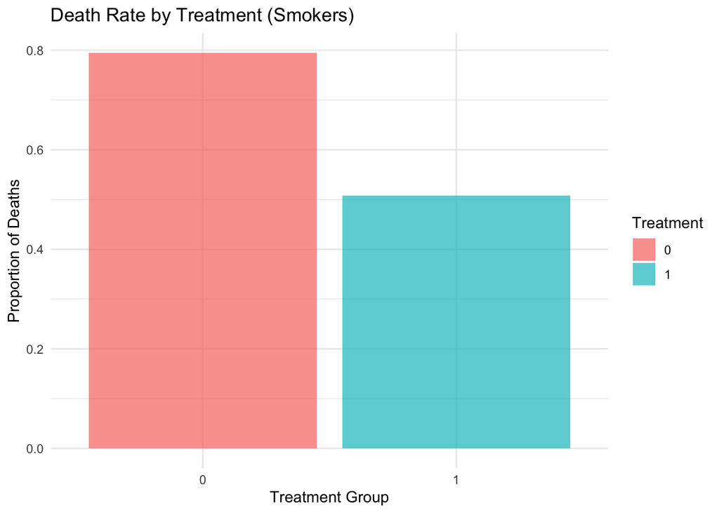

```r
# Proportion of deaths for smokers
smoker_plot <- smoker_data_smoker %>%
  group_by(treatment) %>%
  summarise(death_rate = mean(outcome)) %>%
  ggplot(aes(x = factor(treatment), y = death_rate, fill = factor(treatment))) +
  geom_bar(stat = "identity", alpha = 0.7) +
  labs(
    title = "Death Rate by Treatment (Smokers)",
    x = "Treatment Group",
    y = "Proportion of Deaths",
    fill = "Treatment"
  ) +
  theme_minimal()

print(smoker_plot)
```

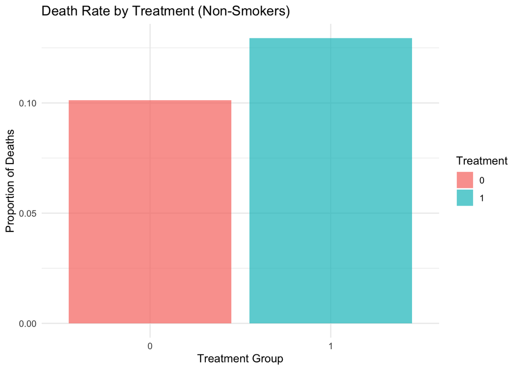

```r
# Proportion of deaths for non-smokers
nosmoker_plot <- smoker_data_nosmoker %>%
  group_by(treatment) %>%
  summarise(death_rate = mean(outcome)) %>%
  ggplot(aes(x = factor(treatment), y = death_rate, fill = factor(treatment))) +
  geom_bar(stat = "identity", alpha = 0.7) +
  labs(
    title = "Death Rate by Treatment (Non-Smokers)",
    x = "Treatment Group",
    y = "Proportion of Deaths",
    fill = "Treatment"
  ) +
  theme_minimal()

print(nosmoker_plot)
```

```r
## Chi-square tests (for dummy variables)
# Create contingency tables
table_smoker <- table(smoker_data_smoker$treatment, smoker_data_smoker$outcome)
table_nosmoker <- table(smoker_data_nosmoker$treatment, smoker_data_nosmoker$outcome)

# Chi-square test for smokers
chisq_test_smoker <- chisq.test(table_smoker)
print(chisq_test_smoker)
```

```
##
##  Pearson's Chi-squared test with Yates' continuity correction
##
## data:  table_smoker
## X-squared = 265.29, df = 1, p-value < 2.2e-16
```

```r
# Chi-square test for non-smokers
chisq_test_nosmoker <- chisq.test(table_nosmoker)
print(chisq_test_nosmoker)
```

```
##
##  Pearson's Chi-squared test with Yates' continuity correction
##
## data:  table_nosmoker
## X-squared = 8.6282, df = 1, p-value = 0.00331
```

# 2. Regressions

## Motivation

For any statistical method (from simple linear regressions to neural networks), our goal is to try and approximate $f(X)$, which is the ‘rule’ or function that describes the relationship between our independent variables $X$ and dependent variable $Y$. This is what a statistical learning / machine learning model does. They can help us *infer* the relationship between independent variables(s) $X$ and dependent variable/outcome $Y$, as well as *predict* future values of an outcome $Y$ given values of $X$.

$$\Large Y = f(X) + e$$
In reality, there is one true $f(X)$ but we don’t know this, because we don’t have the population data to determine this and we cannot precisely account for every factor (i.e, every $X$) in the universe that affects $Y$. Goal of statistics is to figure out $f$, the true relationship between the two. We approximate this relationship $\hat{f(X)}$ using sample data and several assumptions about the functional form. Using our prediction function, we get predicted values of the outcome:

$$\Large \hat{Y} = \hat{f(X)}$$

The accuracy of our function can be measured as the average/expected difference between the true outcome values we have $(Y)$ and the predicted outcomes of our model given values of $X$ $(\hat{Y})$. Our goal here is to minimise the error (difference between the two):

$$\Large E[Y-\hat{Y}] =
E[Y-\hat{f(X)}]$$

## Simple Linear Regression

In conducting linear regression, we are hypothesizing that the relationship between our dependent and independent variables is linear. This can be expressed using the simple linear regression model:

$$\Large Y_i = \beta_0 + \beta_1X_i +
u_i$$
where: - index $i$ covers all the observations - $i = 1,...,n$ - $Y_i$ is the **dependent** variable, also known as **regressand** or **left-side** - $X_i$ is the **independent** variable, also known as **regressor** or **right-side** - $Y = \beta_0 + \beta_1X$ is the **regression line** - $\beta_0$ is the regression line **intercept** - $\beta_1$ is the regression line **slope** (sometimes **coefficient**) - $u_i$ is the **error term**

In practice, $\beta_0$ and $\beta_1$ are unknown, so it is an objective of regression analysis to estimate these parameters. To demonstrate, we will use the real-world example of test scores and student-teacher ratios detailled previously.

$$\Large \hat{Y_i} = \hat{\beta_0} +
\hat{\beta_1}X_i$$

, where the error is the difference between predicted outcome and the true outcome.

Our objective will be to discover the relationship between test scores and student-teacher ratios. We can retrieve data for this experiment from the AER package, installed from CRAN.

From this library, we can load the data set with the function data():

```r
data(CASchools)
```

The CASchools data is made up of California state-wide maths and reading scores for fifth grade students. Class size ratio is measured as students divided by teachers.

We can see that we have a mix of numeric and categorical variables in the data. More importantly, the variables making up our investigation - test score and student-teacher ratio - are not included and will have to be calculated.

## Data processing

For student-teacher ratio, we divide the number of students by number of teachers:

```r
CASchools$st_ratio <- CASchools$students / CASchools$teachers
```

For test scores, we calculate the arithmetic mean of the reading and maths test scores:

```r
CASchools$test_score <- (CASchools$read + CASchools$math)/2
```

Now we have our dataset, let’s generate some summary statistics to better understand the shape and properties of our data. For this, we need to compute three figures: - Sample averages using mean() - Sample standard deviations using sd() - Sample quantiles using quantile()

```r
# print summary to console
summary(CASchools)
```

```
##    district            school                  county      grades
##  Length:420         Length:420         Sonoma     : 29   KK-06: 61
##  Class :character   Class :character   Kern       : 27   KK-08:359
##  Mode  :character   Mode  :character   Los Angeles: 27
##                                        Tulare     : 24
##                                        San Diego  : 21
##                                        Santa Clara: 20
##                                        (Other)    :272
##     students          teachers          calworks          lunch
##  Min.   :   81.0   Min.   :   4.85   Min.   : 0.000   Min.   :  0.00
##  1st Qu.:  379.0   1st Qu.:  19.66   1st Qu.: 4.395   1st Qu.: 23.28
##  Median :  950.5   Median :  48.56   Median :10.520   Median : 41.75
##  Mean   : 2628.8   Mean   : 129.07   Mean   :13.246   Mean   : 44.71
##  3rd Qu.: 3008.0   3rd Qu.: 146.35   3rd Qu.:18.981   3rd Qu.: 66.86
##  Max.   :27176.0   Max.   :1429.00   Max.   :78.994   Max.   :100.00
##
##     computer       expenditure       income          english
##  Min.   :   0.0   Min.   :3926   Min.   : 5.335   Min.   : 0.000
##  1st Qu.:  46.0   1st Qu.:4906   1st Qu.:10.639   1st Qu.: 1.941
##  Median : 117.5   Median :5215   Median :13.728   Median : 8.778
##  Mean   : 303.4   Mean   :5312   Mean   :15.317   Mean   :15.768
##  3rd Qu.: 375.2   3rd Qu.:5601   3rd Qu.:17.629   3rd Qu.:22.970
##  Max.   :3324.0   Max.   :7712   Max.   :55.328   Max.   :85.540
##
##       read            math          st_ratio       test_score
##  Min.   :604.5   Min.   :605.4   Min.   :14.00   Min.   :605.5
##  1st Qu.:640.4   1st Qu.:639.4   1st Qu.:18.58   1st Qu.:640.0
##  Median :655.8   Median :652.5   Median :19.72   Median :654.5
##  Mean   :655.0   Mean   :653.3   Mean   :19.64   Mean   :654.2
##  3rd Qu.:668.7   3rd Qu.:665.9   3rd Qu.:20.87   3rd Qu.:666.7
##  Max.   :704.0   Max.   :709.5   Max.   :25.80   Max.   :706.8
##
```

We now have more insight into the shape of our data, allowing us to identify means, standard deviations and potential outliers.

To make outliers even easier to detect, let’s plot the data on a scatterplot with some helpful annotations:

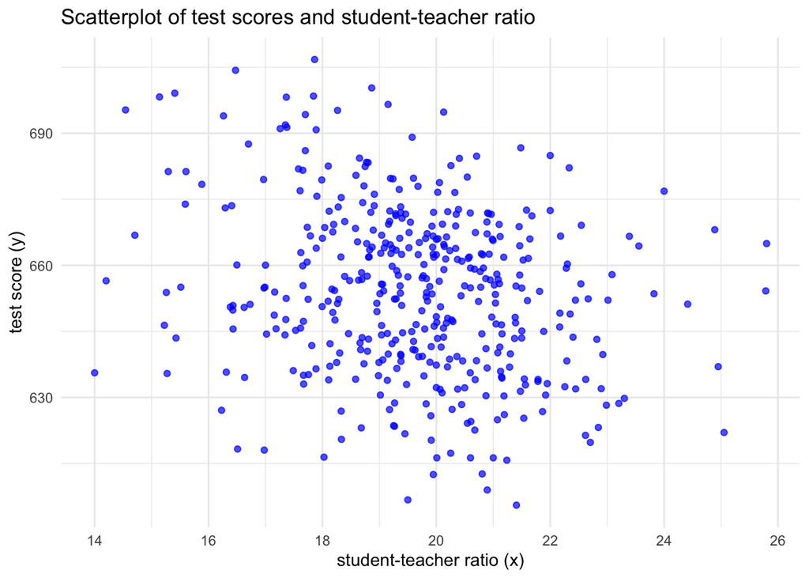

```r
ggplot(CASchools, aes(x = st_ratio, y = test_score)) +
  geom_point(color = "blue", alpha = 0.7) +  # Scatter points
  labs(
    title = "Scatterplot of test scores and student-teacher ratio",  # Title
    x = "student-teacher ratio (x)",  # X-axis label
    y = "test score (y)"  # Y-axis label
  ) +
  theme_minimal()  # Clean minimal theme
```

Correlation is any statistical relationship, whether causal or not, between two random variables or bivariate data.

$$\Large cor(x,y) =
\frac{cov(x,y)}{\sqrt{var(x) \cdot var(y)}}$$

We can see a strong scatter pattern in the data with an apparent negative correlation (we expect to see lower test scores in larger classes). Correlation can be tested by calling cor():

```r
cor(CASchools$st_ratio, CASchools$test_score)
```

```
## [1] -0.2263627
```

A weak negative correlation confirms our observation from the scatterplot. We could now simply eyeball a best-fit line onto the plot based on the correlation, however this would be subjective to each observer of the data (research must be reproducible for it to be reliable!)

## The Ordinary Least Squares (OLS) Estimator

The OLS estimator selects regression coefficients $\beta_0$ and $\beta_1$ such that the regression line will be as “close” to as many data points as possible. ‘Closeness’ in this case is measured by the sum of squared errors made in predicting $Y$ given $X$. In other terms, we want to draw (in econometrics, we say fit a line) that is will have a minimal distance between itself and all observations. This ‘distance’ is squared because of positive and negative distance from the line to the observations.

$$\Large \min_{\hat{\beta_0},
\hat{\beta_1}} \sum_{i=1}^n u_i^2 = \min_{\hat{\beta_0}, \hat{\beta_1}}
\sum_{i=1}^n (Y_i - \hat{Y}i)^2 = \min_{\hat{\beta_0}, \hat{\beta_1}}
\sum_{i=1}^n (Y_i - \hat{\beta_0} - \hat{\beta_1} X_i)^2$$

The OLS estimator is simply the pair of estimators that minimizes this expression. After finding a minimum with respect to both of these coefficients, we get:

$$\Large
\begin{aligned}
\hat{\beta}_1 &= \frac{\sum^n_{i=1}(X_i - \bar{X})(Y_i -
\bar{Y})}{\sum^n_{i=1}(X_i - \bar{X})^2}\\
\\
\hat{\beta}_0 &= \bar{Y} - \hat{\beta}_1\bar{X}
\end{aligned}$$

$\bar{X}$ and $\bar{Y}$ indicate the mean of the $X$ and $Y$ variable respectively.

Note for $\hat{\beta_1}$, after diving by $N-1$, we have covariance of $X$ and $Y$ (how much X and Y vary together on average from their respective means) and variance of $X$ (captures variability of X).

$$\Large
\begin{aligned}
\hat{\beta}_1 &= \frac{\sum^n_{i=1}(X_i - \bar{X})(Y_i -
\bar{Y})}{\sum^n_{i=1}(X_i - \bar{X})^2} = \frac{\frac{\sum^n_{i=1}(X_i
- \bar{X})(Y_i - \bar{Y})}{N-1}}{\frac{\sum^n_{i=1}(X_i -
\bar{X})^2}{N-1}} = \frac{cov(X,Y)}{var(X)}
\end{aligned}$$

Standard Error of Regression ($SER$) is an estimator of the standard deviation of residuals $\hat{u}_i$, essentially it measures the magnitude of a typical deviation from the regression line (a residual):

$$\Large
SER = s_\hat{u} = \sqrt{s^2_\hat{u}} \;where\; s^2\hat{u} = \frac{1}{n -
2} \sum^n_{i=1}\hat{u}^2_i = \frac{SSR}{n - 2}$$

Remember - we don’t observe the error term $u_i$ so we use the estimate $\hat{u}_i$ instead.

To find the $R^2$ and $SER$, we can call summary() on our linear model:

## Calculating OLS Estimators in R

R contains a handy built-in function for performing regression analysis - lm() (linear model). We can call lm() on our data set to obtain an intercept and slope estimate:

```r
# estimate and assign result
lin_model <- lm(test_score ~ st_ratio, data = CASchools)
#print result
summary(lin_model)
```

```
##
## Call:
## lm(formula = test_score ~ st_ratio, data = CASchools)
##
## Residuals:
##     Min      1Q  Median      3Q     Max
## -47.727 -14.251   0.483  12.822  48.540
##
## Coefficients:
##             Estimate Std. Error t value Pr(>|t|)
## (Intercept) 698.9329     9.4675  73.825  < 2e-16 ***
## st_ratio     -2.2798     0.4798  -4.751 2.78e-06 ***
## ---
## Signif. codes:  0 '***' 0.001 '**' 0.01 '*' 0.05 '.' 0.1 ' ' 1
##
## Residual standard error: 18.58 on 418 degrees of freedom
## Multiple R-squared:  0.05124,    Adjusted R-squared:  0.04897
## F-statistic: 22.58 on 1 and 418 DF,  p-value: 2.783e-06
```

$$\begin{aligned}
\Large \hat{\beta_0} = 698.93 \\
\Large \hat{\beta_1} = -2.2798 \\
\end{aligned}$$

$\hat{\beta_1}$ interpretation: for an increase of one unit in student-teacher ratio (i.e., one student per teacher), test scores, on average all else held constant, will decrease by -2.2798 units.

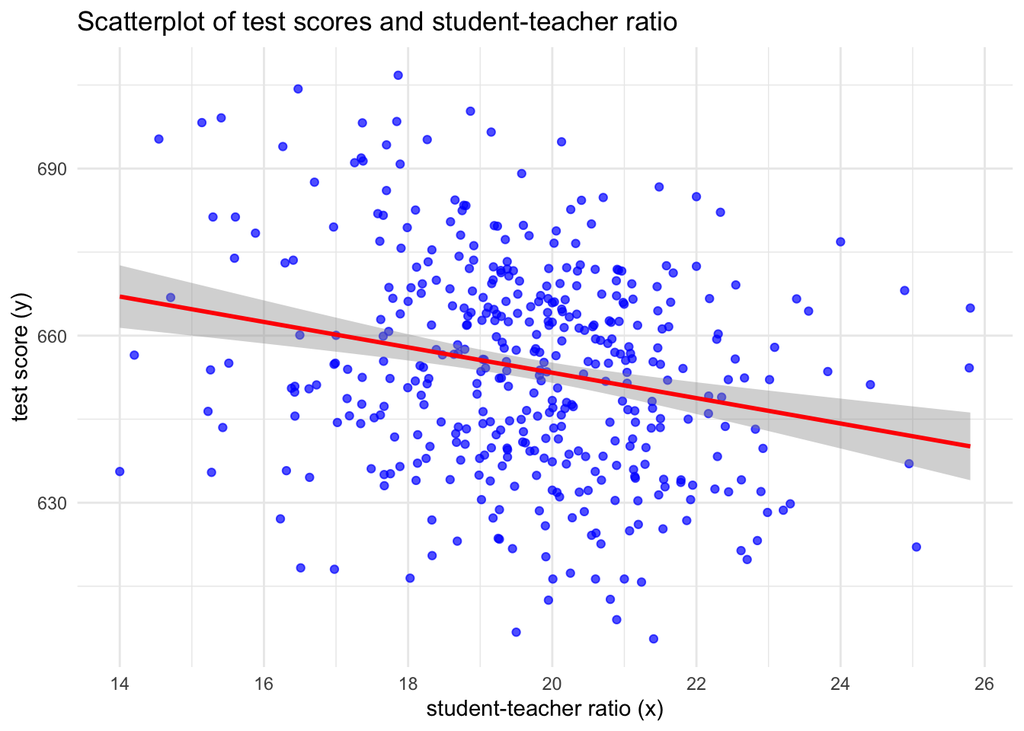

```r
ggplot(CASchools, aes(x = st_ratio, y = test_score)) +
  geom_point(color = "blue", alpha = 0.7) +
  geom_smooth(method = "lm", color = "red", se = TRUE) +  # Add regression line
  labs(
    title = "Scatterplot of test scores and student-teacher ratio",
    x = "student-teacher ratio (x)",
    y = "test score (y)"
  ) +
  theme_minimal()
```

## Hypothesis Testing in the Simple Linear Regression Model

Now we have our regression results, the next task is to test our hypothesis that test scores and teacher-student ratio hold a linear relationship. It is not enough to run a regression and report the intercept and slope! Although they can also be stated as hypothetical ranges of values a variable may take, we state hypothesis when understanding regression coefficients as a binary “yes or no” question that is either accepted or rejected.

Formally, we begin by stating our hypothesis regarding the relationship:

$$\begin{aligned}
\Large H_0 : \beta_1 = 0 \\
\Large H_1 : \beta_1 \neq 0
\end{aligned}$$

$H_0$ forms our null hypothesis, the hypothesis we want to test. $H_1$ is our alternate hypothesis, the hypothesis that is held if the null hypothesis is rejected.

In this scenario, our null hypothesis is that $\beta_1$ (slope) is equal to zero, with the alternate being that $\beta_1$ is not equal to zero. This is a two-sided hypothesis, as $\beta_1$ can take values on either side of the probability distribution (which for we assume to be approximately normal for $\hat{\beta_1}$).

To conduct our test, we need to calculate:

1. The standard error of $\hat{\beta_1}$ ($SE\hat{\beta_1}$). This is a measure of how much our approximation of the slope of the regression line varies.

$$\Large
SE(\hat{\beta_1}) = \sqrt{\hat{\sigma}^2_{\hat{\beta}_1}} =
\sqrt{var({\hat{\beta_1}})}, \hat{\sigma}^2_{\hat{\beta}_1} =
\frac{1}{n} \times
\frac{\frac{1}{n-2}\sum^n_{i=1}(X_i-\bar{X})^2\hat{u}_i^2}{\left[\frac{1}{n}\sum^n_{i=1}(X_i
- \bar{X})^2\right]^2}$$

2. The $t$-statistic, a measure of how much away is the estimated slope coefficient value from the hypothesised one (in our case, $H_0: \beta_1 = 0$, based on the null hypothesis). T-statistic is used for t-distributions, which we use when we have sample data.

$$\Large
\begin{aligned}
t &= \frac{\hat{\beta_1}-\beta_{1,0}}{SE(\hat{\beta_1})}\\
\\
t &= \frac{\text{estimated value} - \text{hypothesized
value}}{\text{standard error of estimator}}
\end{aligned}$$

Using the results from our regression summary, we have the t-statistic:

$$\Large t = \frac{-2.2798 - 0}{0.4798}
\approx -4.75$$

3. The $p$-value, given that we have a two-sided $H_1$:

$$\Large
p-value = Pr_{H_0}
\left[\left|\frac{\hat{\beta}_1-\beta_{1,0}}{SE(\hat{\beta}_1)}\right|>\left|\frac{\hat{\beta}^act_1-\beta_{1,0}}{SE(\hat{\beta}_1)}\right|\right]$$

This notation looks intimidating, but R calculates all this for you! You just need to know what to look for in the output!

Because we have a two-sided hypothesis, we can reject our $H_0$ at $5\%$ significance using two methods:

1. Critical value rejection - our critical value $-4.75$ falls within the rejection region $|Z| < -1.96$
2. $p$-value rejection - our $p$-value is significantly less than $0.05$ ($2.78\cdot10^{-6} < 0.05$).

From this, we can conclude that our $\beta_1$ coefficient is significantly different from zero. Subsequently, we can reject the null hypothesis that class size ($st\_ratio$) has no influence on student’s scores ($test\_scores$) at the $5\%$ level of significance.

Visually, we can demonstrate this with a plot of the $t$ distribution:

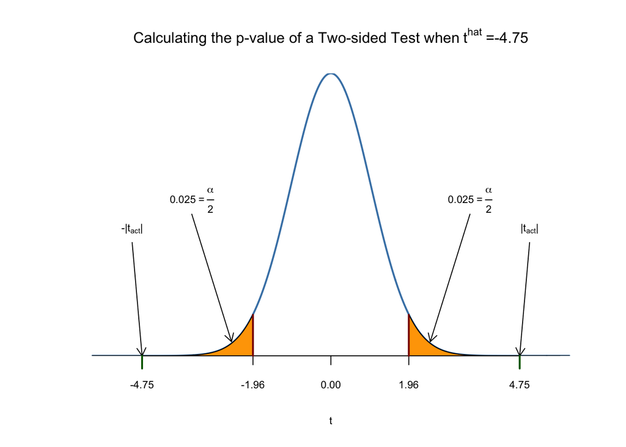

## Measures of Fit

As with any estimation, we want to know how accurate we are! More specifically, we want to know how well our model fits the data. This can be assessed visually by the degree of clustering the data points have around the regression line. Numerically, we can call on the coefficient of determination - known as $R^2$. $R^2$ is the fraction of the sample variance of $Y_i$ that is explained by $X_i$. Mathematically, this is the ratio of the explained sum of squares ($ESS$) to the total sum of squares ($TSS$).

$$\Large R^2 =
\frac{ESS}{TSS}$$

Since $TSS$ = $ESS$ + $SSR$ (or $RSS$), we have:

$$\Large R^2 = \frac{TSS-RSS}{TSS} =
1-\frac{RSS}{TSS}$$

The $ESS$ is the sum of squared deviations from the predicted values $\hat{Y}_i$, from their average $\bar{Y_i}$:

$$\Large
ESS = \sum^n_{i-1}(\hat{Y}_i - \bar{Y})^2$$

The $TSS$ is the sum of squared deviations from $Y_i$ from their average $\bar{Y}_i$

$$\Large
TSS = \sum^n_{i-1}(Y_i - \bar{Y})^2$$

$SSR$ is a measure of errors made when predicting $Y$ by $X$, defined as:

$$\Large
SSR = \sum^n_{i=1}\hat{u}^2_i$$

The resulting $R^2$ figure lies between 0 and 1, where 1 indicates perfect fit (no errors made) $(ESS=TSS)$ and 0 $(ESS=0)$ indicates no fit.

```r
mod_summary <- summary(lin_model)
# print summary
mod_summary
```

```
##
## Call:
## lm(formula = test_score ~ st_ratio, data = CASchools)
##
## Residuals:
##     Min      1Q  Median      3Q     Max
## -47.727 -14.251   0.483  12.822  48.540
##
## Coefficients:
##             Estimate Std. Error t value Pr(>|t|)
## (Intercept) 698.9329     9.4675  73.825  < 2e-16 ***
## st_ratio     -2.2798     0.4798  -4.751 2.78e-06 ***
## ---
## Signif. codes:  0 '***' 0.001 '**' 0.01 '*' 0.05 '.' 0.1 ' ' 1
##
## Residual standard error: 18.58 on 418 degrees of freedom
## Multiple R-squared:  0.05124,    Adjusted R-squared:  0.04897
## F-statistic: 22.58 on 1 and 418 DF,  p-value: 2.783e-06
```

Our $R^2$ is $0.051$, so $5.1\%$ of the variance in dependent variable test_score is explained by explanatory variable st_ratio. Additionally, the $SER$ is $18.58$, meaning that the average deviation between the actual test score and the regression line is $18.58$ points.

The rejection region is highlighted in yellow, being where our $t$-statistic resides.

## The Multiple Linear Regression Model

Simple linear regression analysis is fine for illustrating the fundamentals of analysing a relationship between variables, but it is majorly flawed in that it does not consider other determinants of the dependent variable ($test\_score$) that correlate with the independent variable ($st\_ratio$). In other words, there are other explanatory elements in the relationship that we are not identifying with our model.

In OLS regression, we assume that our variables are linearly independent ([more info here](https://www.econometrics-with-r.org/4.4-tlsa.html)). However, we may violate this assumption and induce bias if we do not include determinants of the dependent variable that vary with the independent variable (recall that influences on $test\_score$ that are not captured are collected as the error term $u$).

Ultimately, if we do not capture these additional determinants, we will wrongly estimate the causal effect on $test\_score$ of a unit change in $st\_ratio$ - known as **Omitted Variable Bias**

### Introducing New Independent Variables

In the CASchools data set we have many other variables that may cause bias if they are omitted from the model. A potentially relevant omitted variable could be the percentage of English learners in the school district. It stands to reason that the ability to speak, read, and write English is an important factor in successful learning. Additionally, it is possible that the portion of English learner students is bigger in school districts where class sizes are relatively large - i.e. in poor urban districts with higher population of immigrants. Therefore, English learner students are likely to perform worse in assessments than native speakers.

We can demonstrate the difference including percentage of English learners has on the model by computing correlations between $st\_ratio$, $test\_score$, and $english$:

```r
cor(CASchools$st_ratio, CASchools$test_score)
```

```
## [1] -0.2263627
```

```r
cor(CASchools$st_ratio, CASchools$english)
```

```
## [1] 0.1876424
```

We are already familiar with the negative correlation between $st\_ratio$ and $test\_score$, where smaller class sizes appear to positively influence test scores (or, as class sizes grow, scores appear to decrease). However, the sign of the correlation between $st\_ratio$ and $english$ is positive - meaning that as class sizes grow, percentage of English learners increases.

Where this becomes problematic in regression analysis is how the estimators become biased. Presently, our estimator $\hat{\beta_1}$ is suggesting that smaller class sizes improve test scores. But $\hat{\beta_1}$ is also overestimating the effect of small classes because it is not capturing the effects of having fewer English learners.

Therefore, we need to update our regression model to include $english$ as an independent variable:

$$\Large
Y_i = \beta_0 + \beta_1X_{1i} + \beta_2X_{2i} + u_i$$

or in the context of our data:

$$\Large
test\_score = \beta_0 + \beta_1 \cdot st\_ratio + \beta_2 \cdot english
+ other factors$$

### Estimating Multivariate Regression

Let’s estimate both models and see the difference:

```r
# estimate models
linear_mod <- lm(test_score ~ st_ratio, data = CASchools)
multi_mod <- lm(test_score ~ st_ratio + english, data = CASchools)
```

```r
# print results
linear_mod
```

```
##
## Call:
## lm(formula = test_score ~ st_ratio, data = CASchools)
##
## Coefficients:
## (Intercept)     st_ratio
##      698.93        -2.28
```

```r
multi_mod
```

```
##
## Call:
## lm(formula = test_score ~ st_ratio + english, data = CASchools)
##
## Coefficients:
## (Intercept)     st_ratio      english
##    686.0322      -1.1013      -0.6498
```

Note that we still perform multiple regressions with lm(), we just add variables onto the right hand side.

### Multiple Regression Models

In estimating multiple regressions, we must remember the important principle of *ceteris paribus* - Latin for “all else being equal”.

Multiple regression models may contain many independent variables, and we need to reliably estimate the effects on dependent variable $Y_i$ of changing independent variable $X_{1i}$ if remaining right-side variables $X_{2i}, X_{3i},...,X_{ki}$ do not change (are held equal).

In our model, coefficient scores on $st\_ratio$ are interpreted as the effect on $test\_score$ of a **one unit** change in $st\_ratio$ if $english$ is held constant.

Similar to the simple regression model, we assume that the true relationship between dependent and independent variables is linear with an error term $u$ that we cannot observe.

The full multiple regression model with $k$ right-hand side variables is therefore:

$$\Large
Y_i = \beta_0 + \beta_1X_{1i} + \beta_2X_{2i} + \beta_3X_{3i} + \cdot
\cdot \cdot + \beta_kX_{ki} + u_i, i = 1,...,n$$

We can call summary() on our multiple regression model to see the estimated coefficients:

```r
summary(multi_mod)$coef
```

```
##                Estimate Std. Error    t value      Pr(>|t|)
## (Intercept) 686.0322445 7.41131160  92.565565 3.871327e-280
## st_ratio     -1.1012956 0.38027827  -2.896026  3.978059e-03
## english      -0.6497768 0.03934254 -16.515882  1.657448e-47
```

We now have three dimensions to our data, $test\_score$($\beta_0$), $st\_ratio$($\beta_1$), and $english$($\beta_2$), which is reflected in the predictions given in the summary output. Subsequently, we can no longer represent our data in a two dimensional plot, but in a three dimensional space. Furthermore, the regression line becomes the regression plane.

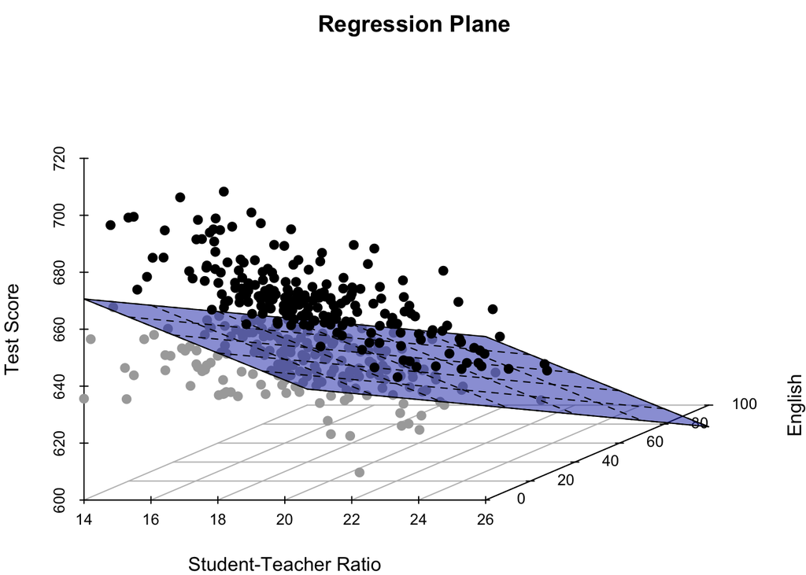

We can see that the model appears to fit the data reasonably well, with many points being clustered around the regression plane. Naturally, we have some points that do not fit as well (remember we still have $u$ in the model!), as the added dimension of English speaking ability cannot explain away the unobserved error.

### Measures of Fit in the Multiple Linear Regression Model

Let’s now call the full summary for our multiple regression model:

```r
summary(multi_mod)
```

```
##
## Call:
## lm(formula = test_score ~ st_ratio + english, data = CASchools)
##
## Residuals:
##     Min      1Q  Median      3Q     Max
## -48.845 -10.240  -0.308   9.815  43.461
##
## Coefficients:
##              Estimate Std. Error t value Pr(>|t|)
## (Intercept) 686.03224    7.41131  92.566  < 2e-16 ***
## st_ratio     -1.10130    0.38028  -2.896  0.00398 **
## english      -0.64978    0.03934 -16.516  < 2e-16 ***
## ---
## Signif. codes:  0 '***' 0.001 '**' 0.01 '*' 0.05 '.' 0.1 ' ' 1
##
## Residual standard error: 14.46 on 417 degrees of freedom
## Multiple R-squared:  0.4264, Adjusted R-squared:  0.4237
## F-statistic:   155 on 2 and 417 DF,  p-value: < 2.2e-16
```

We retain our previously covered measures of fit $R^2$ and standard error of regression $SER$ in multivariate regression, but now we are also interested in the adjusted-$R^2$, or $\bar{R}^2$

$R^2$ alone is no longer reliable for measuring goodness-of-fit for our model, because it’s value increases with each right-side variable we add to the model. We could very easily game our analysis by adding many variables to our model, which decreases the $SSR$ and causes over-fitting in our model. $\bar{R}^2$ applies a penalty to each added variable $k$ by using a correction factor, calculated:

$$\Large
\bar{R}^2 = 1 - \frac{n-1}{n-k-1}\frac{SSR}{TSS}$$

The question remains - have we improved our model fit with the addition of another independent variable? We can compare the $\bar{R}^2$ from each model to find out!

```r
summary(linear_mod)$adj.r.squared
```

```
## [1] 0.04897033
```

```r
summary(multi_mod)$adj.r.squared
```

```
## [1] 0.4236805
```

We can see a vast improvement in $\bar{R}^2$ between the two models!